# Placebo Effect

12/21/2017

Largely following:

> Senn S. 2011. Francis Galton and regression to the mean. *Significance* 8:124–126.

## Data

Generate baseline data with a mean of 90 for $n$ subjects. Add normally distributed offset (i.e., the treatment has no effect, and the second measure goes up or down randomly).

```r
set.seed(3247543)

n <- 1000
Baseline <- rnorm(n, mean = 90, sd = 7)
Outcome <- Baseline + rnorm(n, mean = 0, sd = 5)
```

Set a `cutoff` of 95 for “Hypertensive”, and calculate the difference between the Baseline and Outcome measures. Color code groups and plot.

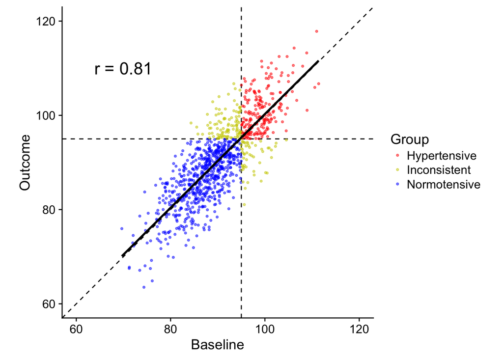

```r
cutoff <- 95

M <- tibble(Baseline, Outcome)

# Categorize groups
M <- M %>%
  mutate(
    Group = case_when(
    Baseline > cutoff & Outcome > cutoff ~ "Hypertensive",
    Baseline < cutoff & Outcome < cutoff ~ "Normotensive",
    TRUE ~ "Inconsistent"),
    Difference = Outcome - Baseline)

M %>% ggplot(aes(Baseline, Outcome, color = Group)) +
  geom_abline(slope = 1, intercept = 0, linetype = "dashed") +
  geom_vline(xintercept = cutoff, linetype = "dashed") +
  geom_hline(yintercept = cutoff, linetype = "dashed") +
  geom_point(alpha = 0.5, size = 0.75) +
  geom_smooth(aes(group = 1), method = "lm", se = FALSE, color = "black") +
  annotate("text",
           label = paste("r =", round(cor(M$Baseline, M$Outcome), 2)),
           x = 70, y = 110, size = 6) +
  scale_color_manual(values = c("red", "yellow3", "blue")) +
  coord_fixed() +
  xlim(c(60, 120)) +
  ylim(c(60, 120))
```

Across the three groups, there is no mean effect (red line).

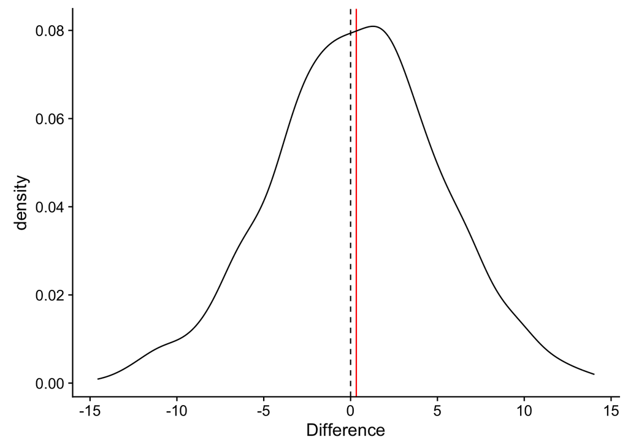

```r
M %>%
  ggplot(aes(Difference)) +
  geom_vline(xintercept = mean(M$Difference), color = "red") +
  geom_vline(xintercept = 0, linetype = "dashed") +
  geom_line(stat = "density")
```

Within groups, there is a bimodal distribution in the Inconsistent group. Some go up, and some go down. The problem is that half of this distribution will be truncated by only considering the group with Baseline measurements > 95.

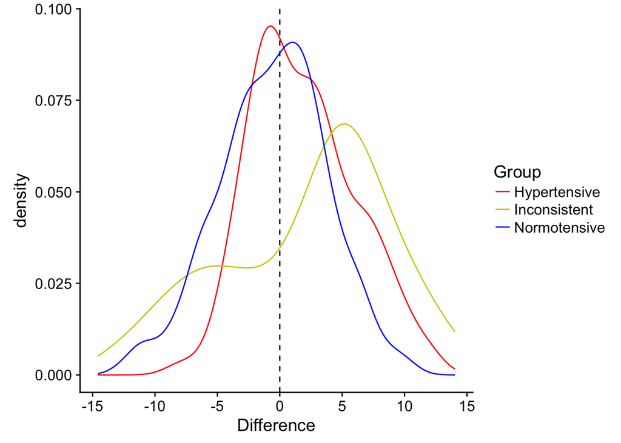

```r
M %>%
  ggplot(aes(Difference, color = Group)) +
  geom_vline(xintercept = 0, linetype = "dashed") +
  geom_line(stat = "density") +
  scale_color_manual(values = c("red", "yellow3", "blue"))
```

## Hypertensive only

Consider only those with Baseline measurements > 95.

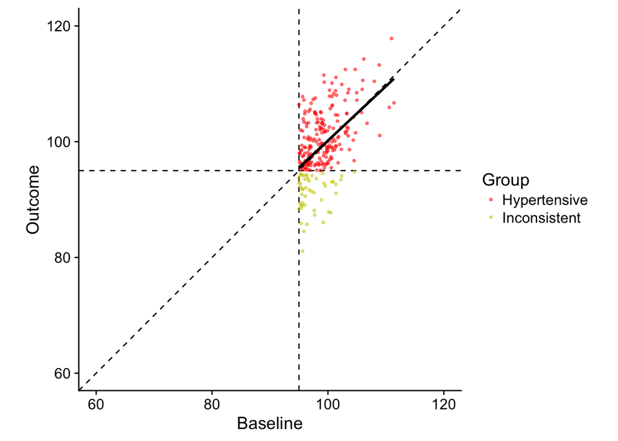

```r
M_hyp <- M %>%
  filter(Baseline > cutoff)

ggplot(M_hyp, aes(Baseline, Outcome, color = Group)) +
  geom_abline(slope = 1, intercept = 0, linetype = "dashed") +
  geom_vline(xintercept = cutoff, linetype = "dashed") +
  geom_hline(yintercept = cutoff, linetype = "dashed") +
  geom_point(alpha = 0.5, size = 0.75) +
  scale_color_manual(values = c("red", "yellow3", "blue")) +
  geom_smooth(aes(group = 1), method = "lm", se = FALSE, color = "black") +
  coord_fixed() +
  xlim(c(60, 120)) +
  ylim(c(60, 120))
```

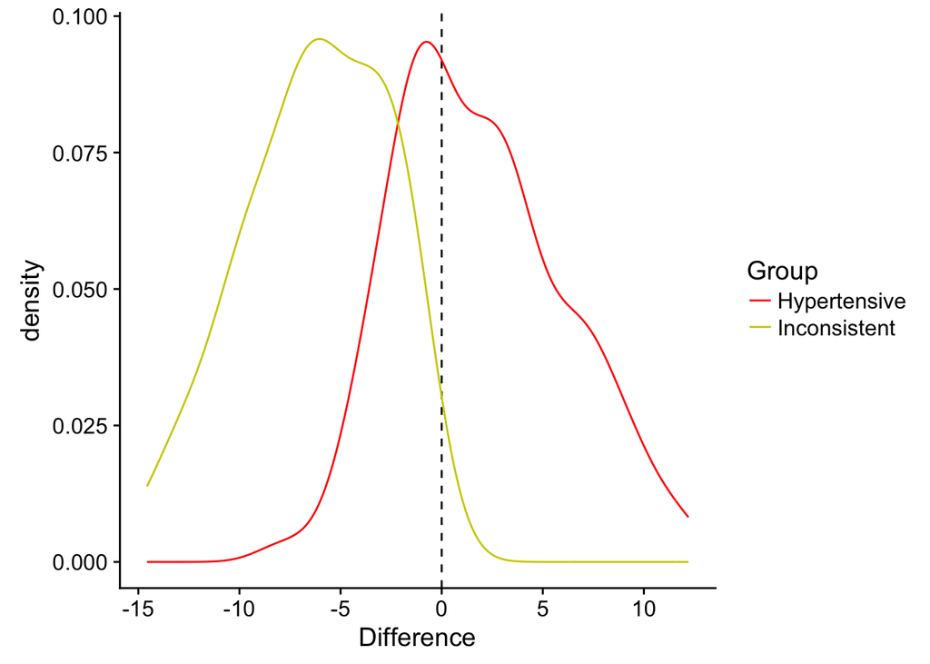

```r
ggplot(M_hyp, aes(Difference, color = Group)) +
  geom_vline(xintercept = 0, linetype = "dashed") +
  geom_line(stat = "density") +
  scale_color_manual(values = c("red", "yellow3", "blue"))
```

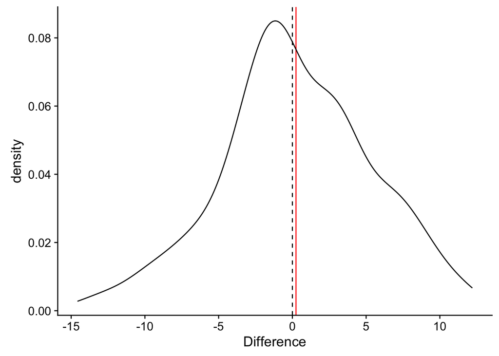

```r
ggplot(M_hyp, aes(Difference)) +
  geom_vline(xintercept = mean(M_hyp$Difference), color = "red") +
  geom_vline(xintercept = 0, linetype = "dashed") +
  geom_line(stat = "density")
```